# Report for Flipt Data Challenge

## Importing Libraries

```python
%matplotlib inline

# numbers
import numpy as np
import pandas as pd

# stats
import statsmodels.api as sm
import scipy.stats as stats

# plots
import matplotlib.pyplot as plt
import seaborn as sns

# utils
import os, re

# removing warnings
import sys

if not sys.warnoptions:
    import warnings
    warnings.simplefilter("ignore")

# setting pandas display representation for better visualiation of calculations
pd.set_option('display.float_format', lambda x: '%.5f' % x)

from numpy.random import seed
from numpy.random import randn
#from scipy.stats import shapiro
from scipy.stats import normaltest
#from scipy.stats import anderson
```

## Loading the data in a dataframe

```python
df = pd.read_excel ('Simulation_Results_Sample_Data.xlsx', skiprows=[0])
df = df.rename(columns={'total cost': 'total_cost'})
df.head()

#df.to_excel( 'r_test.xlsx',sheet_name= 'test')
```

|  | simulation | awp_trend | vol_trend | retail_generic | retail_brand | retail_specialty | mail_generic | mail_brand | mail_specialty | total_cost |
| --- | --- | --- | --- | --- | --- | --- | --- | --- | --- | --- |
| 0 | 1 | Mid AWP Trend | High Vol Trend | 1102882.19741 | 5736866.66995 | 0 | 110182.04513 | 529694.87755 | 3813658.04136 | 11293283.83141 |
| 1 | 2 | Mid AWP Trend | Low Vol Trend | 1078466.96286 | 5707554.28245 | 0 | 108472.30660 | 529694.87755 | 3868907.23597 | 11293095.66544 |
| 2 | 3 | Low AWP Trend | High Vol Trend | 1105221.18504 | 5653310.83131 | 0 | 110252.76566 | 527809.09913 | 3862627.32270 | 11259221.20384 |
| 3 | 4 | Mid AWP Trend | Mid Vol Trend | 1091182.82302 | 5727511.11822 | 0 | 109954.24498 | 529694.87755 | 3833823.49093 | 11292166.55470 |
| 4 | 5 | High AWP Trend | Mid Vol Trend | 1092138.74447 | 5811196.94618 | 0 | 109636.84899 | 531580.65597 | 3965510.52041 | 11510063.71603 |

## Generalized plotting function to plot distributions

```python
def plotDistribution(plottingVariable):
    fig = plt.figure(figsize=(12,9))
    plt.title('Distribution')
    sns.distplot(plottingVariable, bins=50)
```

## Function to test distribution

```python
def normalityTest(testData):

    # D'Agostino and Pearson's Test
    data = testData
    # normality test
    stat, p = normaltest(data)
    print('Statistics=%.3f, p=%.3f' % (stat, p))
    # interpret
    alpha = 0.05
    if p > alpha:
        print('Sample looks Gaussian (fail to reject H0)')
    else:
        print('Sample does not look Gaussian (reject H0)')
```

## 1. Explore the various costs by low/mid/high volume trends, and by low/mid/high AWP trends, then create visualizations.

For the visualization part there are two processes carried out:

Data manipulation in R using gather function

Data Visualization front end in Tableau

### The HTML file attached below is the manipulation of data in R tidyverse with R Markdown and the data exported to create Tableau Dashboards

```python
from IPython.display import HTML

HTML(filename='Data Manipulation in R.html')
```

Data Manipulation

```
library(tidyr)
```

```
library(readxl)
```

```
library(xlsx)
```

Loading the clean excel file from python for R manipulation

```
data <- read_xlsx("C:/Users/joelj/Desktop/Flipt/r_test.xlsx")
```

```
## * `` -> ...1
```

```
head(data)
```

```
## # A tibble: 6 x 11
##    ...1 simulation awp_trend vol_trend retail_generic retail_brand
##   <dbl>      <dbl> <chr>     <chr>              <dbl>        <dbl>
## 1     0          1 Mid AWP ~ High Vol~       1102882.     5736867.
## 2     1          2 Mid AWP ~ Low Vol ~       1078467.     5707554.
## 3     2          3 Low AWP ~ High Vol~       1105221.     5653311.
## 4     3          4 Mid AWP ~ Mid Vol ~       1091183.     5727511.
## 5     4          5 High AWP~ Mid Vol ~       1092139.     5811197.
## 6     5          6 Low AWP ~ Mid Vol ~       1089429.     5622653.
## # ... with 5 more variables: retail_specialty <dbl>, mail_generic <dbl>,
## #   mail_brand <dbl>, mail_specialty <dbl>, total_cost <dbl>
```

Using he gather function to tidy the data for analysis in Tableau

```
gather_data <- gather(data = data, key = "Type", value = "Cost", retail_generic:mail_specialty)
head(gather_data)
```

```
## # A tibble: 6 x 7
##    ...1 simulation awp_trend     vol_trend    total_cost Type          Cost
##   <dbl>      <dbl> <chr>         <chr>             <dbl> <chr>        <dbl>
## 1     0          1 Mid AWP Trend High Vol Tr~  11293284. retail_ge~  1.10e6
## 2     1          2 Mid AWP Trend Low Vol Tre~  11293096. retail_ge~  1.08e6
## 3     2          3 Low AWP Trend High Vol Tr~  11259221. retail_ge~  1.11e6
## 4     3          4 Mid AWP Trend Mid Vol Tre~  11292167. retail_ge~  1.09e6
## 5     4          5 High AWP Tre~ Mid Vol Tre~  11510064. retail_ge~  1.09e6
## 6     5          6 Low AWP Trend Mid Vol Tre~  11130274. retail_ge~  1.09e6
```

Removing the total cost column for analysis in Tableau

```
gather_data_final <- gather_data[,-5]
head(gather_data_final)
```

```
## # A tibble: 6 x 6
##    ...1 simulation awp_trend      vol_trend      Type               Cost
##   <dbl>      <dbl> <chr>          <chr>          <chr>             <dbl>
## 1     0          1 Mid AWP Trend  High Vol Trend retail_generic 1102882.
## 2     1          2 Mid AWP Trend  Low Vol Trend  retail_generic 1078467.
## 3     2          3 Low AWP Trend  High Vol Trend retail_generic 1105221.
## 4     3          4 Mid AWP Trend  Mid Vol Trend  retail_generic 1091183.
## 5     4          5 High AWP Trend Mid Vol Trend  retail_generic 1092139.
## 6     5          6 Low AWP Trend  Mid Vol Trend  retail_generic 1089429.
```

Exporting the file as excel to be leaded in Tableau

```
write.csv(gather_data_final, "gather_data_final1.csv")
```

## Embedding the Tableau dashboard

```python
%%HTML
<div class='tableauPlaceholder' id='viz1593064787990' style='position: relative'><noscript><a href='#'><img alt=' ' src='https:&#47;&#47;public.tableau.com&#47;static&#47;images&#47;pb&#47;pbmFLIPT&#47;Part-1&#47;1_rss.png' style='border: none' /></a></noscript><object class='tableauViz'  style='display:none;'><param name='host_url' value='https%3A%2F%2Fpublic.tableau.com%2F' /> <param name='embed_code_version' value='3' /> <param name='site_root' value='' /><param name='name' value='pbmFLIPT&#47;Part-1' /><param name='tabs' value='no' /><param name='toolbar' value='yes' /><param name='static_image' value='https:&#47;&#47;public.tableau.com&#47;static&#47;images&#47;pb&#47;pbmFLIPT&#47;Part-1&#47;1.png' /> <param name='animate_transition' value='yes' /><param name='display_static_image' value='yes' /><param name='display_spinner' value='yes' /><param name='display_overlay' value='yes' /><param name='display_count' value='yes' /><param name='language' value='en' /></object></div>                <script type='text/javascript'>                    var divElement = document.getElementById('viz1593064787990');                    var vizElement = divElement.getElementsByTagName('object')[0];                    if ( divElement.offsetWidth > 800 ) { vizElement.style.width='1600px';vizElement.style.height='827px';} else if ( divElement.offsetWidth > 500 ) { vizElement.style.width='1600px';vizElement.style.height='827px';} else { vizElement.style.width='100%';vizElement.style.height='1427px';}                     var scriptElement = document.createElement('script');                    scriptElement.src = 'https://public.tableau.com/javascripts/api/viz_v1.js';                    vizElement.parentNode.insertBefore(scriptElement, vizElement);                </script>
```

[figure not shown]

## Analysis of the dashboard

The Analysis begins with the general overview of the two trends AWP and Volume with high, medium, and low and the total cost of each segment as below:

- Retail
  - Generic
  - Brand
  - Speciality
- Mail
  - Generic
  - Brand
  - Speciality

From the overall distribution in the pie charts, we do not see any significant insights as the high, medium, and low segments showing similar costs.

However, when we drill down to each segment for each of the trend we find that the low trend of both AWP and Volume have lesser overall cost of drugs

## 2. Explore the various costs by the 9 trend combinations, and create visualizations.

Tableau visualization of the 9 trend combination is created and embedded in this notebook as well below. The same data manipulated with R is used for this analysis.

```python
%%HTML
<div class='tableauPlaceholder' id='viz1593066917687' style='position: relative'><noscript><a href='#'><img alt=' ' src='https:&#47;&#47;public.tableau.com&#47;static&#47;images&#47;pb&#47;pbmFLIPT-2&#47;Part-2&#47;1_rss.png' style='border: none' /></a></noscript><object class='tableauViz'  style='display:none;'><param name='host_url' value='https%3A%2F%2Fpublic.tableau.com%2F' /> <param name='embed_code_version' value='3' /> <param name='site_root' value='' /><param name='name' value='pbmFLIPT-2&#47;Part-2' /><param name='tabs' value='no' /><param name='toolbar' value='yes' /><param name='static_image' value='https:&#47;&#47;public.tableau.com&#47;static&#47;images&#47;pb&#47;pbmFLIPT-2&#47;Part-2&#47;1.png' /> <param name='animate_transition' value='yes' /><param name='display_static_image' value='yes' /><param name='display_spinner' value='yes' /><param name='display_overlay' value='yes' /><param name='display_count' value='yes' /><param name='language' value='en' /></object></div>                <script type='text/javascript'>                    var divElement = document.getElementById('viz1593066917687');                    var vizElement = divElement.getElementsByTagName('object')[0];                    if ( divElement.offsetWidth > 800 ) { vizElement.style.width='1400px';vizElement.style.height='927px';} else if ( divElement.offsetWidth > 500 ) { vizElement.style.width='1400px';vizElement.style.height='927px';} else { vizElement.style.width='100%';vizElement.style.height='777px';}                     var scriptElement = document.createElement('script');                    scriptElement.src = 'https://public.tableau.com/javascripts/api/viz_v1.js';                    vizElement.parentNode.insertBefore(scriptElement, vizElement);                </script>
```

[figure not shown]

## Analysis of the dashboard

The dashboard contains two components:

The 9 trend combination and its effects on the overall price segments

Cost by segment without the 9 trend combinations

From the first plot, we derive the following insights:

Low AWP-Mid Vol has the lowest overall cost whereas the Mid AWP-Mid Vol has the highest overall cost

The AWP trend vs the Low Vol and Mid Vol follow a similar pattern in which the order of increasing cost is low, high medium.

However, the High Vol trend vs the AWP trend shows a different order with Medium lowest then High and then Low

From the second plot, we derive the following insights:

In the Retail segment, branded drugs have the highest total cost with speciality drugs having no cost

In the Mail segment, the pattern reverses with speciality drugs having the highest overall cost and brand drugs having a lower cost

Generic drugs in mail segment have very low share of cost whereas in the retil segment, generic drugs have a decent share

## 3. Regardless of the trend combinations, what does the distribution look like for the 1000 results (total cost)? Is it normal distribution? If not, why do you think it’s not normal?

### Test for normality

The D'Agostino and Pearson's Test rejects the null hypothesis and statistically proves that the distribution is not normal

```python
normalityTest(df['total_cost'])
```

```
Statistics=346.940, p=0.000
Sample does not look Gaussian (reject H0)
```

### Plot Analysis

By plotting the distributions, we can graphically confirm the normality test as the distribution is clearly not normal. However we notice 3 major modes and needs further investigation on why do we see this multimodal distribution.

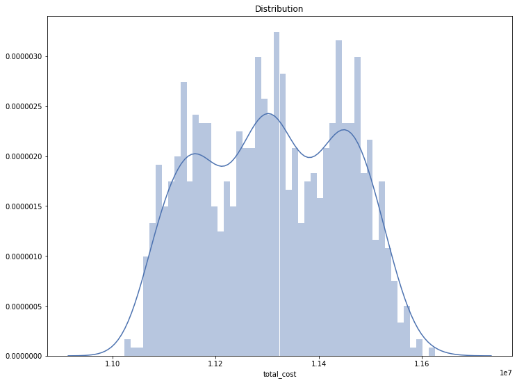

```python
plotDistribution(df['total_cost'])
```

## Investigation on why the distribution is not normal

```python
p = df[df.awp_trend == 'High AWP Trend']
q = df[df.awp_trend == 'Mid AWP Trend']
r = df[df.awp_trend == 'Low AWP Trend']
```

### Plot Analysis

With further investigation by splitting the AWP trends to high medium low and then plotting the distributions of each of the separate subsamples, we clearly see that the reason for the multimodal aspect in the total cost was caused by the AWP trend. The AWP trend's high, medium, and low creates 3 separate normal distributions.

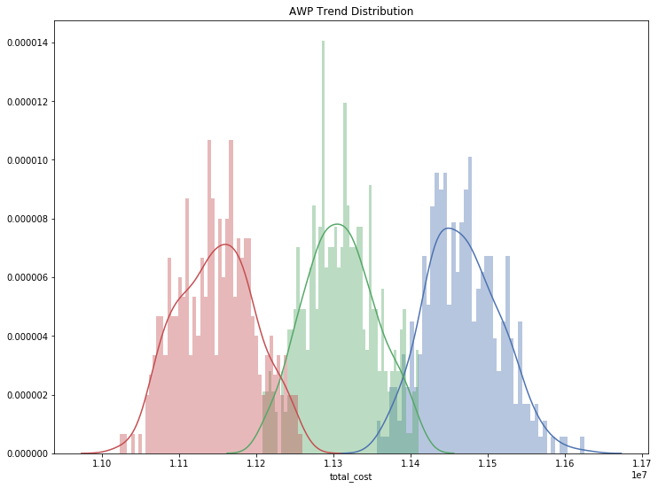

```python
fig = plt.figure(figsize=(12,9))
plt.title('AWP Trend Distribution')
sns.distplot(p['total_cost'], bins=50)
sns.distplot(q['total_cost'], bins=50)
sns.distplot(r['total_cost'], bins=50)
```

```python
a = df[df.vol_trend == 'High Vol Trend']
b = df[df.vol_trend == 'Mid Vol Trend']
c = df[df.vol_trend == 'Low Vol Trend']
```

### Plot Analysis

The volume trend has a mixed distribution and does not contribute to the multimodal aspect of the total cost distribution

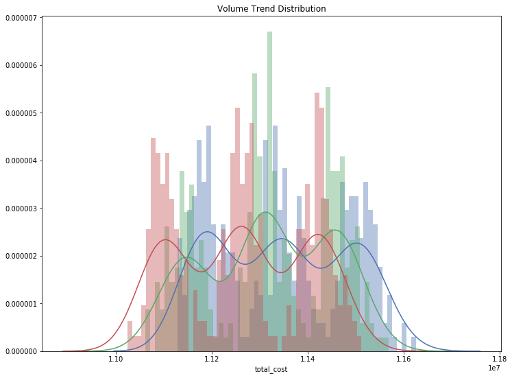

```python
fig = plt.figure(figsize=(12,9))
plt.title('Volume Trend Distribution')
sns.distplot(a['total_cost'], bins=50)
sns.distplot(b['total_cost'], bins=50)
sns.distplot(c['total_cost'], bins=50)
```

## 4. Subset the data for the Mid Vol Trend and Mid AWP Trend combination. Plot the total cost distribution for the subset.

```python
x = df[df.awp_trend == 'Mid AWP Trend']
mid_trend = x[x.vol_trend == 'Mid Vol Trend']
```

```python
mid_trend.head()
```

|  | simulation | awp_trend | vol_trend | retail_generic | retail_brand | retail_specialty | mail_generic | mail_brand | mail_specialty | total_cost |
| --- | --- | --- | --- | --- | --- | --- | --- | --- | --- | --- |
| 3 | 4 | Mid AWP Trend | Mid Vol Trend | 1091182.82302 | 5727511.11822 | 0 | 109954.24498 | 529694.87755 | 3833823.49093 | 11292166.55470 |
| 15 | 16 | Mid AWP Trend | Mid Vol Trend | 1090593.89639 | 5746392.52191 | 0 | 109354.78637 | 529694.87755 | 3831816.87136 | 11307852.95358 |
| 17 | 18 | Mid AWP Trend | Mid Vol Trend | 1089711.06703 | 5724661.39300 | 0 | 110029.75230 | 529694.87755 | 3864956.60082 | 11319053.69070 |
| 38 | 39 | Mid AWP Trend | Mid Vol Trend | 1090057.15854 | 5749732.59865 | 0 | 109658.07814 | 529694.87755 | 3847021.16316 | 11326163.87605 |
| 45 | 46 | Mid AWP Trend | Mid Vol Trend | 1091633.12877 | 5714513.16183 | 0 | 110732.07591 | 529694.87755 | 3857823.86811 | 11304397.11217 |

### Test for normality

The D'Agostino and Pearson's Test accepts the null hypothesis and statistically proves that the distribution is normal

```python
normalityTest(mid_trend['total_cost'])
```

```
Statistics=5.894, p=0.053
Sample looks Gaussian (fail to reject H0)
```

### Plot Analysis

By plotting the distributions, we can graphically confirm the normality test as the distribution is normal.

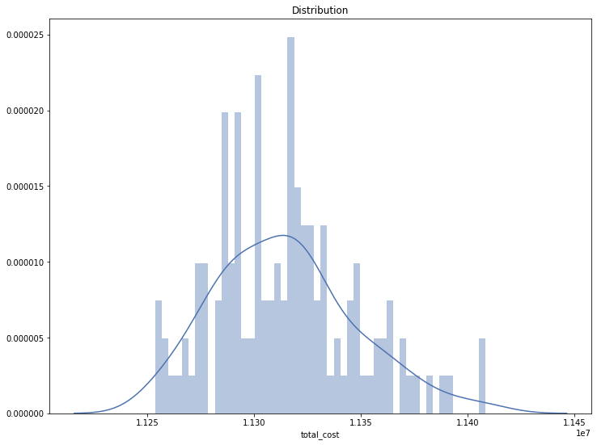

```python
plotDistribution(mid_trend['total_cost'])
```

## 5. a) For the same subset above, randomly assign one of the three saving percentages (10%/15%/20%) to each row, and calculate the total cost after savings in a new column:

### total cost after savings = total cost * (1 - savings %)

```python
mid_trend_saving = mid_trend

#Randomly assigning 10%, 15%, and 20% to the rows with 33.33% probability
mid_trend_saving['savings'] = mid_trend_saving['simulation'].transform(lambda x: np.random.choice([0.1,0.15,0.2]))
```

```python
mid_trend_saving.head()
```

|  | simulation | awp_trend | vol_trend | retail_generic | retail_brand | retail_specialty | mail_generic | mail_brand | mail_specialty | total_cost | savings |
| --- | --- | --- | --- | --- | --- | --- | --- | --- | --- | --- | --- |
| 3 | 4 | Mid AWP Trend | Mid Vol Trend | 1091182.82302 | 5727511.11822 | 0 | 109954.24498 | 529694.87755 | 3833823.49093 | 11292166.55470 | 0.15000 |
| 15 | 16 | Mid AWP Trend | Mid Vol Trend | 1090593.89639 | 5746392.52191 | 0 | 109354.78637 | 529694.87755 | 3831816.87136 | 11307852.95358 | 0.10000 |
| 17 | 18 | Mid AWP Trend | Mid Vol Trend | 1089711.06703 | 5724661.39300 | 0 | 110029.75230 | 529694.87755 | 3864956.60082 | 11319053.69070 | 0.10000 |
| 38 | 39 | Mid AWP Trend | Mid Vol Trend | 1090057.15854 | 5749732.59865 | 0 | 109658.07814 | 529694.87755 | 3847021.16316 | 11326163.87605 | 0.15000 |
| 45 | 46 | Mid AWP Trend | Mid Vol Trend | 1091633.12877 | 5714513.16183 | 0 | 110732.07591 | 529694.87755 | 3857823.86811 | 11304397.11217 | 0.15000 |

```python
#Applying the formula on the dataframe to calculate cost after savings

mid_trend_saving['total_cost_after_savings'] = mid_trend_saving.total_cost * (1-mid_trend_saving.savings)
```

```python
mid_trend_saving.head()
```

|  | simulation | awp_trend | vol_trend | retail_generic | retail_brand | retail_specialty | mail_generic | mail_brand | mail_specialty | total_cost | savings | total_cost_after_savings |
| --- | --- | --- | --- | --- | --- | --- | --- | --- | --- | --- | --- | --- |
| 3 | 4 | Mid AWP Trend | Mid Vol Trend | 1091182.82302 | 5727511.11822 | 0 | 109954.24498 | 529694.87755 | 3833823.49093 | 11292166.55470 | 0.15000 | 9598341.57149 |
| 15 | 16 | Mid AWP Trend | Mid Vol Trend | 1090593.89639 | 5746392.52191 | 0 | 109354.78637 | 529694.87755 | 3831816.87136 | 11307852.95358 | 0.10000 | 10177067.65822 |
| 17 | 18 | Mid AWP Trend | Mid Vol Trend | 1089711.06703 | 5724661.39300 | 0 | 110029.75230 | 529694.87755 | 3864956.60082 | 11319053.69070 | 0.10000 | 10187148.32163 |
| 38 | 39 | Mid AWP Trend | Mid Vol Trend | 1090057.15854 | 5749732.59865 | 0 | 109658.07814 | 529694.87755 | 3847021.16316 | 11326163.87605 | 0.15000 | 9627239.29464 |
| 45 | 46 | Mid AWP Trend | Mid Vol Trend | 1091633.12877 | 5714513.16183 | 0 | 110732.07591 | 529694.87755 | 3857823.86811 | 11304397.11217 | 0.15000 | 9608737.54534 |

## 5. b) What does the distribution look like? Plot the distribution curve in the same graph as in #4.

### Hint: it will look similar to #4, but with lower average.

### Test for normality

The D'Agostino and Pearson's Test rejects the null hypothesis and statistically proves that the distribution is not normal

```python
normalityTest(mid_trend_saving['total_cost_after_savings'])
```

```
Statistics=117.938, p=0.000
Sample does not look Gaussian (reject H0)
```

### Plot Analysis

By plotting the distributions, we can graphically confirm the normality test as the distribution is not normal.

There are certain differences with my assumptions and the hint provided. Kindly find my analysis below:

The data points in the simulation are close to eachother

Subtracting the cost with the 3 percentages have brought the values of the cost close together forming three clusters

The three clusters are clearly seen in the graph below. Changing the bins do not affect the graph distribution in anyway

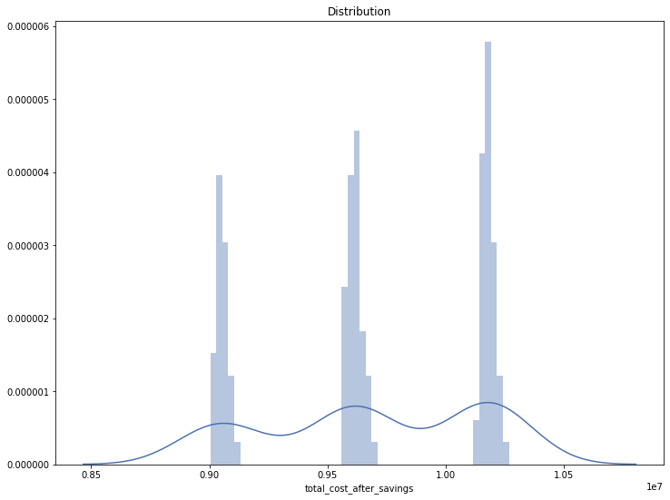

```python
plotDistribution(mid_trend_saving['total_cost_after_savings'])
```

```python
def plotDistribution_new(plottingVariable1,plottingVariable2):
    fig = plt.figure(figsize=(12,9))
    plt.title('Combined Distribution')
    sns.distplot(plottingVariable1, bins=30)
    sns.distplot(plottingVariable2, bins=30)
```

### Plotting both the total cost with the total cost after savings together we find

The cost savings have created 3 clusters of close values but the average has reduces as stated in te assumption. However the distribution is different from the normal distribution of the total cost observed in #4

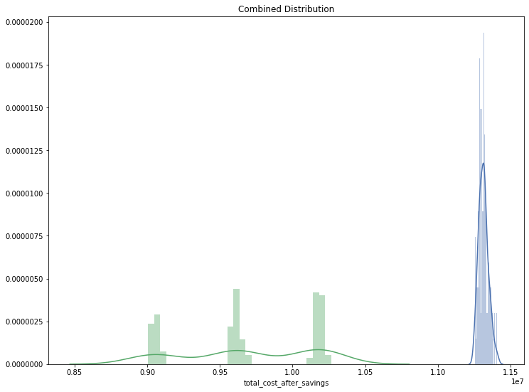

```python
plotDistribution_new(mid_trend_saving['total_cost'],mid_trend_saving['total_cost_after_savings'])
```